# phone_churn_2

# Split data

This churn_index will help randomly select 555 observations from the churn class.

```r
churn_index = which(data_dummified$churn %in% c('true'))[sample.int(5000, 5000 / 9)]
length(churn_index)
```

```
[1] 555
```

data_dummified_restored_original_prop has 5000 + 555 = 5555 observations.

```r
data_dummified_not_churn = data_dummified[data_dummified$churn == 'false', ]
data_dummified_churn_subset = data_dummified[churn_index, ]
data_dummified_restored_original_prop = rbind(data_dummified_not_churn, data_dummified_churn_subset)
```

One dataset for decision tree and one dataset for KNN and NB.

```r
set.seed(123)
data_split_for_tree = makeResampleInstance(desc = 'Holdout',
                                           task = makeClassifTask(data = data_dummified,
                                                                  target = 'churn'),
                                           split = 0.7,
                                           stratify = TRUE)
data_split_for_KNN_and_NB =
  makeResampleInstance(desc = 'Holdout',
                       task = makeClassifTask(data = data_dummified_restored_original_prop,
                                              target = 'churn'),
                       split = 0.7,
                       stratify = TRUE)
```

# Decision Tree

Apart from the following process, in Week 8 Warm Up, function makeTuneWrapper provides more convenience.

```r
rdesc = makeResampleDesc("CV", iters = 5, stratify = TRUE)
task = makeClassifTask(data = data_dummified[data_split_for_tree$train.inds[[1]],  ], target = 'churn')
lrn_tree = makeLearner(cl = "classif.rpart", predict.type ='prob')
ps_tree = makeParamSet(makeNumericParam('cp', lower = 0.001, upper = 0.03),
                       makeIntegerParam('maxdepth', lower = 2, upper = 30))
ctrl_tree = makeTuneControlRandom(maxit = 40L)
res_tree = tuneParams(learner = lrn_tree,
                      task = task,
                      resampling = rdesc,
                      par.set = ps_tree,
                      control = ctrl_tree,
                      show.info =FALSE)
```

### Optional: See if there is still potential to improve parameter values.

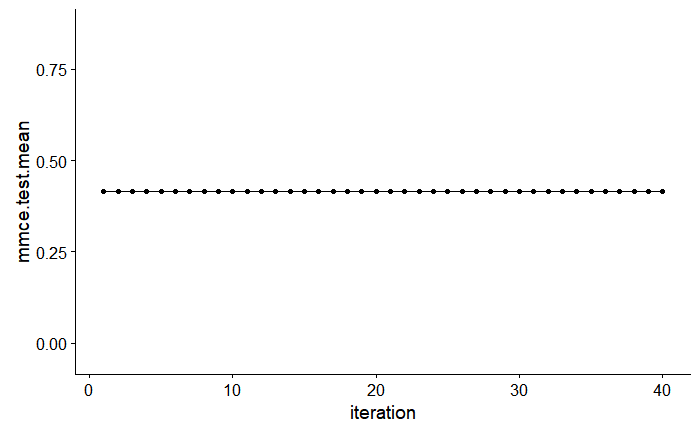

```r
psdata_tree = generateHyperParsEffectData(res_tree)
plotHyperParsEffect(psdata_tree, x = "iteration", y = "mmce.test.mean", plot.type = "line")
```

### Construct a learner with the tuned parameters.

```r
lrn_tree_tuned = setHyperPars(lrn_tree, par.vals = res_tree$x)
```

## Feature Selection

```r
ncol(data)
```

```
[1] 32
```

### Run spsa on tuned and not-tuned learner

```r
spsaMod_tree_tuned = spFeatureSelection(task, wrapper = lrn_tree_tuned,
                              measure = auc, num.features.selected = 0)
```

```
SPSA-FSR begins:
Wrapper = rpart
Measure = auc
Number of selected features = 0
```

```
iter  value   st.dev  num.ft  best.value
1     0.59586 0.00962 29      0.59586 *
2     0.59828 0.01349 21      0.59828 *
3     0.59311 0.01359 22      0.59828
4     0.58634 0.01653 22      0.59828
5     0.59136 0.01348 26      0.59828
6     0.59512 0.01395 25      0.59828
7     0.59952 0.01225 22      0.59952 *
8     0.59757 0.01658 23      0.59952
9     0.59869 0.01003 22      0.59952
10    0.59667 0.01717 24      0.59952
11    0.59226 0.01503 24      0.59952
12    0.59706 0.01731 27      0.59952
13    0.60034 0.01451 26      0.60034 *
14    0.59548 0.0171  27      0.60034
```

[output cut: 48 more lines]

```
Best iteration = 42
Number of selected features = 23
Best measure value = 0.60817
Std. dev. of best measure = 0.01608
Run time = 10.1 minutes.
```

```r
spsaMod_tree = spFeatureSelection(task, wrapper = lrn_tree,
                              measure = auc, num.features.selected = 0)
```

```
SPSA-FSR begins:
Wrapper = rpart
Measure = auc
Number of selected features = 0
```

```
iter  value   st.dev  num.ft  best.value
1     0.59468 0.0221  20      0.59468 *
2     0.59121 0.0147  19      0.59468
3     0.59591 0.01307 23      0.59591 *
4     0.59505 0.01532 21      0.59591
5     0.58219 0.01077 17      0.59591
6     0.59315 0.01632 19      0.59591
7     0.59373 0.01618 19      0.59591
8     0.59249 0.00695 18      0.59591
9     0.59035 0.02095 17      0.59591
10    0.58086 0.0141  17      0.59591
11    0.58167 0.00981 23      0.59591
12    0.58133 0.01164 23      0.59591
13    0.58143 0.01281 23      0.59591
14    0.57967 0.01256 23      0.59591
```

[output cut: 43 more lines]

```
Best iteration = 37
Number of selected features = 24
Best measure value = 0.59839
Std. dev. of best measure = 0.01228
Run time = 7.94 minutes.
```

### Optional: Save the best features as JSON

```r
spsaFeatures_tree = list( tunedLearnerFeatures   = spsaMod_tree_tuned$features,
                     untunedLearnerFeatures = spsaMod_tree$features)
write(toJSON( spsaFeatures_tree, auto_unbox = TRUE, pretty = TRUE, factor = 'string'),
      'spsaFeatures_tree.txt')
```

### Extract the spsa task (with the set of reduced number of features)

```r
#spsaTask_tree_tuned = spsaMod_tree_tuned$task.spfs
spsaBestModel_tree_tuned  = spsaMod_tree_tuned$best.model
#spsaTask_tree = spsaMod_tree$task.spfs
spsaBestModel_tree = spsaMod_tree$best.model
```

### Importance ploting

```r
spFSR::getImportance( spsaMod_tree_tuned )
```

| features | importance |
| --- | --- |
| lifeTime | 0.55219 |
| handsetAge | 0.54183 |
| avgMins | 0.53683 |
| true.1 | 0.52648 |
| avgrecurringCharge | 0.52416 |
| numHandsets | 0.52134 |
| regionType.suburban | 0.52089 |
| true.2 | 0.52036 |
| lastMonthCustomerCareCalls | 0.51881 |
| marriageStatus.unknown | 0.51858 |

[output cut: 13 more lines]

```r
spFSR::getImportance( spsaMod_tree )
```

| features | importance |
| --- | --- |
| lifeTime | 0.56889 |
| true.1 | 0.54632 |
| age | 0.53746 |
| true | 0.53483 |
| occupation.retired | 0.53005 |
| creditRating.B | 0.52825 |
| avgInCalls | 0.52464 |
| avgMins | 0.51871 |
| avgDroppedCalls | 0.51716 |
| marriageStatus.yes | 0.51665 |

[output cut: 14 more lines]

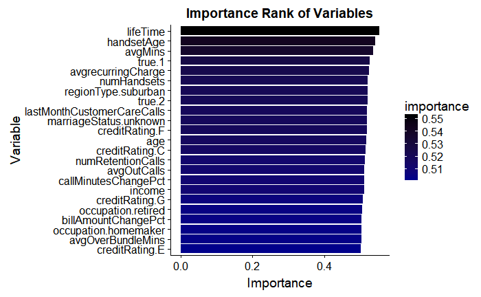

```r
spFSR::plotImportance( spsaMod_tree_tuned )
```

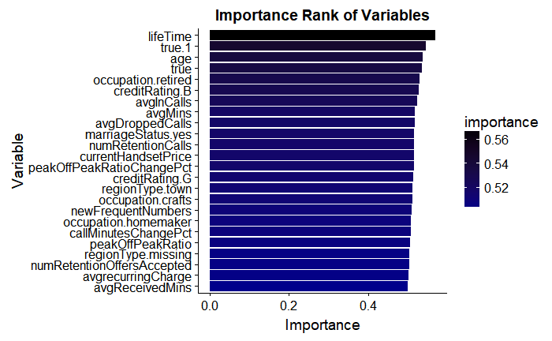

```r
spFSR::plotImportance( spsaMod_tree )
```

## Train models

Only need to train the model that was tuned but did not go through the feature selection process. No need to train the model given by SPSA, since the “best.model” object from SPSA has already been trained.

```r
m = mlr::train(learner = lrn_tree_tuned, task = task)
```

## Define the test data (the task)

```r
task_test = makeClassifTask(data = data_dummified[data_split_for_tree$test.inds[[1]],  ], target = 'churn')
```

## Predict

```r
pred_on_test       = predict(object = m, task = task_test)
pred_on_test_spsa_tree_tuned = predict(object = spsaBestModel_tree_tuned, task = task_test)
pred_on_test_spsa_tree = predict(object = spsaBestModel_tree, task = task_test)
```

## Evaluation

We may get the confusion matrix by running calculateConfusionMatrix(pred_on_test), but more importantly, we need to get the ROC.

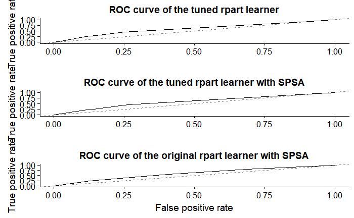

```r
d  = generateThreshVsPerfData(pred_on_test, measures = list(fpr, tpr))
d_spsa_tree_tuned = generateThreshVsPerfData(pred_on_test_spsa_tree_tuned, measures = list(fpr, tpr))
d_spsa_tree = generateThreshVsPerfData(pred_on_test_spsa_tree, measures = list(fpr, tpr))
p = plotROCCurves(d) + labs(title = 'ROC curve of the tuned rpart learner', x = "")
p_spsa_tree_tuned = plotROCCurves(d_spsa_tree_tuned) +
  labs(title = 'ROC curve of the tuned rpart learner with SPSA', x = "")
p_spsa_tree = plotROCCurves(d_spsa_tree) + labs(title = 'ROC curve of the original rpart learner with SPSA')
library(cowplot)
plot_grid(p, p_spsa_tree_tuned, p_spsa_tree, align = 'v', ncol = 1) # Run this line in console to visualise better.
```

## Remark

1. pred_on_test is based on the tuned learner
2. pred_on_test_spsa_tree_tuned is based on the tuned learner + spsa
3. pred_on_test_spsa_tree is based on the original learner + spsa

Tuning and running spsa yield the best result.

```r
performance(pred_on_test,  measures = auc)
```

```
      auc
0.6022573
```

```r
performance(pred_on_test_spsa_tree_tuned, measures = auc)
```

```
      auc
0.6027327
```

```r
performance(pred_on_test_spsa_tree, measures = auc)
```

```
      auc
0.5997333
```

# KNN

We will first tune the model and then do SPSA feature selection. The process is very similar to decision tree modelling, but the visualisation is skipped.

```r
CV_and_train_data_KNN_and_NB =
  data_dummified_restored_original_prop[data_split_for_KNN_and_NB$train.inds[[1]],]
test_data_KNN_and_NB =
  data_dummified_restored_original_prop[data_split_for_KNN_and_NB$test.inds[[1]],]
rdesc = makeResampleDesc("CV", iters = 5, stratify = TRUE)
task = makeClassifTask(data = CV_and_train_data_KNN_and_NB, target = 'churn')
lrn_KNN = makeLearner(cl = "classif.kknn", predict.type ='prob')
ps_KNN = makeParamSet(makeIntegerParam('k', lower = 1, upper = 30))
ctrl_KNN = makeTuneControlGrid()
res_KNN = tuneParams(learner = lrn_KNN,
                      task = task,
                      resampling = rdesc,
                      par.set = ps_KNN,
                      control = ctrl_KNN,
                      show.info =FALSE)
lrn_KNN_tuned = setHyperPars(lrn_KNN, par.vals = res_KNN$x)
spsaMod_KNN_tuned = spFeatureSelection(task,
                                       wrapper = lrn_KNN_tuned,
                                       measure = auc,
                                       num.features.selected = 0)
```

```
SPSA-FSR begins:
Wrapper = kknn
Measure = auc
Number of selected features = 0
```

```
iter  value   st.dev  num.ft  best.value
1     0.55144 0.03523 16      0.55144 *
2     0.5105  0.02344 19      0.55144
3     0.51972 0.02987 20      0.55144
4     0.53095 0.02027 18      0.55144
5     0.53299 0.0301  19      0.55144
6     0.53945 0.02681 17      0.55144
7     0.5732  0.02596 20      0.5732 *
8     0.58474 0.02899 19      0.58474 *
9     0.5781  0.02676 19      0.58474
10    0.57024 0.0269  21      0.58474
11    0.5628  0.03495 22      0.58474
12    0.56434 0.0243  22      0.58474
13    0.5722  0.02624 21      0.58474
14    0.56738 0.0365  20      0.58474
15    0.56869 0.03657 20      0.58474
16    0.55473 0.03302 20      0.58474
17    0.56967 0.02015 21      0.58474
18    0.56348 0.02139 21      0.58474
19    0.56734 0.03288 21      0.58474
20    0.55347 0.02258 21      0.58474
21    0.55375 0.02865 21      0.58474
22    0.5466  0.03022 21      0.58474
23    0.56938 0.03101 20      0.58474
24    0.55821 0.03374 18      0.58474
25    0.57203 0.02996 19      0.58474
26    0.56311 0.02195 18      0.58474
27    0.55612 0.02937 18      0.58474
28    0.5575  0.04295 17      0.58474
```

```
Best iteration = 8
Number of selected features = 19
Best measure value = 0.58474
Std. dev. of best measure = 0.02899
Run time = 5.57 minutes.
```

```r
task_test = makeClassifTask(data = test_data_KNN_and_NB, target = 'churn')
pred_on_test_spsa_KNN_tuned = predict(object = spsaMod_KNN_tuned$best.model,
                                      task = task_test)
performance(pred_on_test_spsa_KNN_tuned, measures = auc)
```

```
      auc
0.5515469
```

### Take a look at the best hyperparameter.

```r
lrn_KNN_tuned
```

```
Learner classif.kknn from package kknn
Type: classif
Name: k-Nearest Neighbor; Short name: kknn
Class: classif.kknn
Properties: twoclass,multiclass,numerics,factors,prob
Predict-Type: prob
Hyperparameters: k=24
```

# Naive Bayes

We will first tune the model and then do SPSA feature selection. The process is very similar to decision tree modelling, but the visualisation is skipped.

```r
CV_and_train_data_KNN_and_NB =
  data_dummified_restored_original_prop[data_split_for_KNN_and_NB$train.inds[[1]],]
test_data_KNN_and_NB =
  data_dummified_restored_original_prop[data_split_for_KNN_and_NB$test.inds[[1]],]
rdesc = makeResampleDesc("CV", iters = 5, stratify = TRUE)
task = makeClassifTask(data = CV_and_train_data_KNN_and_NB, target = 'churn')
lrn_NB = makeLearner(cl = "classif.naiveBayes", predict.type ='prob')
ps_NB = makeParamSet(makeNumericParam('laplace', lower = 0, upper = 10))
ctrl_NB = makeTuneControlRandom(maxit = 20L)
res_NB = tuneParams(learner = lrn_NB,
                      task = task,
                      resampling = rdesc,
                      par.set = ps_NB,
                      control = ctrl_NB,
                      show.info =FALSE)
lrn_NB_tuned = setHyperPars(lrn_NB, par.vals = res_NB$x)
spsaMod_NB_tuned = spFeatureSelection(task,
                                      wrapper = lrn_NB_tuned,
                                      measure = auc,
                                      num.features.selected = 0)
```

```
SPSA-FSR begins:
Wrapper = nbayes
Measure = auc
Number of selected features = 0
```

```
iter  value   st.dev  num.ft  best.value
1     0.58195 0.04228 21      0.58195 *
2     0.58966 0.0394  24      0.58966 *
3     0.58318 0.02807 23      0.58966
4     0.59405 0.02285 18      0.59405 *
5     0.59189 0.03279 22      0.59405
6     0.59208 0.03208 22      0.59405
7     0.58239 0.03366 22      0.59405
8     0.58913 0.04186 22      0.59405
9     0.59639 0.02994 20      0.59639 *
10    0.58533 0.02037 20      0.59639
11    0.58531 0.03174 20      0.59639
12    0.59888 0.04091 20      0.59888 *
13    0.59574 0.03932 20      0.59888
14    0.59011 0.02187 16      0.59888
```

[output cut: 43 more lines]

```
Best iteration = 37
Number of selected features = 16
Best measure value = 0.60515
Std. dev. of best measure = 0.02876
Run time = 24.53 minutes.
```

```r
task_test = makeClassifTask(data = test_data_KNN_and_NB, target = 'churn')
pred_on_test_spsa_NB_tuned = predict(object = spsaMod_NB_tuned$best.model,
                                     task = task_test)
performance(pred_on_test_spsa_NB_tuned, measures = auc)
```

```
      auc
0.6114012
```

### Take a look at the best hyperparameter.

```r
lrn_NB_tuned
```

```
Learner classif.naiveBayes from package e1071
Type: classif
Name: Naive Bayes; Short name: nbayes
Class: classif.naiveBayes
Properties: twoclass,multiclass,missings,numerics,factors,prob
Predict-Type: prob
Hyperparameters: laplace=8.94
```

# Conclusion

- AUC Decision Tree: 0.60
- AUC KNN: 0.55
- AUC Naive Bayes:0.61